# Introduction rapide à Rmarkdown

# 1. Créer un document Rmarkdown

Un document R Markdown est un fichier texte enregistré avec l’extension `.Rmd`.

Sous RStudio, on peut créer un nouveau document en allant dans le menu `File` puis en choisissant `New file` puis `R Markdown…`. La boîte de dialogue suivante s’affiche :

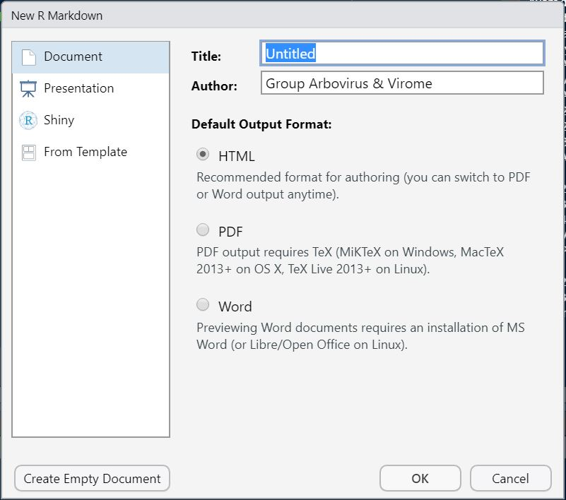

Nouveau document Rmarkdown

On peut indiquer le titre, l’auteur du document ainsi que le format de sortie par défaut (possibilité de modifier facilement ces éléments par la suite). De plus, on peut aussi choisir de créer une présentation sous forme de slides (*Presentation*) ou de créer un document à partir d’un modèle (*From Template*).

# 2. Eléments composants un document Rmarkdown

## 2.1. En tête

La première partie du document est l’en-tête. Il se situe eu début du document, et est délimité par trois tirets (`---`) avant et après. Cette partie est extrêmement personnalisable, c’est notamment ici que l’on peut changer le format du document (si volonté de le modifier après la création), changer la police, le fond et bien d’autres :

```
---
title: "Introduction rapide à Rmarkdown"
author: "Group Arbovirus & Virome"
date: "16/02/2023"
output: rmdformats::readthedown
---
```

## 2.2. Texte du document

Le corps du document est constitué de texte qui suit la syntaxe *Markdown*. Un fichier Markdown est un fichier texte contenant un balisage léger qui permet de définir des niveaux de titres ou de mettre en forme le texte. Par exemple, le texte suivant :

```
Texte en *italique* ou en **gras**

Liste à puces :

* Niveau 1 (1)
  + Niveau 2 (1)
  + Niveau 2 (2)
* Niveau 1 (2)

Niveaux de titres :

# Niveau 1
## Niveau 2
### Niveau 3

Insertion liens ou images (ce qu'il y a entre crochets est le nom du lien ou la légende de l'image) :

[Exemple de lien](https://example.com) ou <https://example.com>
![Exemple d'image](Images/example.jpg)
```

Pour les *tableaux*, la syntaxe est un peu particulière :

```
Table Header  | Second Header
------------- | -------------
Table Cell    | Cell 2
Cell 3        | Cell 4
```

Dans RStudio, le menu `Help` puis `Markdown quick reference` donne un aperçu plus complet de la syntaxe.

## 2.3. Blocs de code

### 2.3.1. Blocs de code simples

Pour intégrer des blocs de code simples à du texte voici la syntaxe :

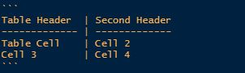

Bloc de code simple

### 2.3.2. Blocs de code R

En plus du texte libre et des blocs de code simples au format *Markdown*, un document R Markdown contient, comme son nom l’indique, du code R. Celui-ci est inclus dans des blocs (**chunks**) délimités par la syntaxe suivante :

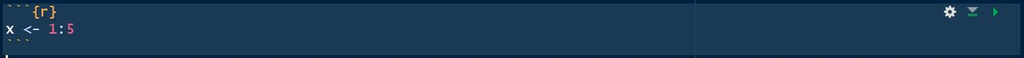

Bloc de code R

Comme cette suite de caractères n’est pas très simple à saisir, vous pouvez utiliser le menu `Insert` de RStudio et choisir `R`, ou utiliser le raccourci clavier `Ctrl+Alt+i`

Quand votre curseur se trouve dans un bloc, vous pouvez saisir le code R que vous souhaitez, l’exécuter, utiliser l’autocomplétion, exactement comme si vous vous trouviez dans un script R. Vous pouvez également exécuter l’ensemble du code contenu dans un bloc à l’aide du raccourci clavier `Ctrl+Maj+Entrée` ou alors avec la petite flèche verte en haut à droite du code. De même vous pouvez utiliser le menu `Run` pour lancer un bloc de code (`Run Current Chunk`) ou tous les blocs de code précédents ou suivants (`Run All Chunks Above` ou `Run All Chunks Below`).

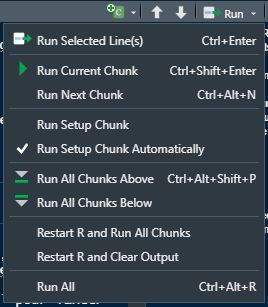

Lancer code R

## 2.4. Compiler un document (*Knit*)

On peut à tout moment compiler (**Knit**) un document *R Markdown* pour obtenir et visualiser le document généré. Pour cela, il suffit de cliquer sur le bouton `Knit` et de choisir le format de sortie voulu :

[figure not shown]

Compiler un document

Vous pouvez aussi utiliser le raccourci `Ctrl+Maj+K` pour compiler le document dans le dernier format utilisé.

*PS : Pour la génération du format PDF, vous devez avoir une installation fonctionnelle de LaTeX sur votre système.*

*Si ça n’est pas le cas, l’extension tinytex de Yihui Xie vise à faciliter l’installation d’une distribution LaTeX minimale quel que soit le système d’exploitation de votre machine. Pour l’utiliser il vous faut d’abord installer l’extension avec install.packages(‘tinytex’), puis lancer la commande suivante dans la console (prévoir un téléchargement d’environ 200Mo) :*

```
tinytex::install_tinytex()
```

# 3. Personnaliser le document

La personnalisation du document généré se fait en modifiant des options dans le préambule du document. *RStudio* propose néanmoins une petite interface graphique permettant de changer ces options plus facilement. Pour cela, cliquez sur l’icône en forme d’engrenage à droite du bouton `Knit` et choisissez `Output Options…`

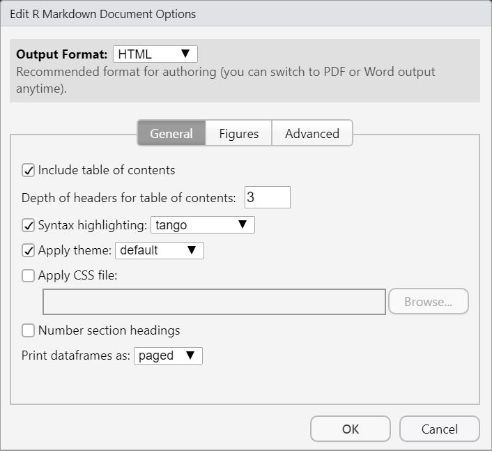

Personnaliser un document

Lorsque vous changez des options, *RStudio* va modifier le préambule de votre document. Il est possible de spécifier des options différentes selon les formats, par exemple :

```
---
title: "PROCEDURE POUR ANALYSER LES DONNEES DU VIROME EN SORTIE DU PIPELINE"
author: Group Arbovirus & Virome
date: "17/02/2023"
output:
  html_document:
    toc: yes
    toc_depth: 4
    toc_float: true
    number_sections: false
    highlight: tango
    df_print: paged
    code_hiding: TRUE
    code_folding: show
  pdf_document:
    toc: true
    toc_depth: 4
    number_sections: false
    highlight: tango
    df_print: kable
---
```

La liste complète des options possibles est présente sur le [site de la documentation officielle](https://rmarkdown.rstudio.com/formats.html)

# 4. Options des blocs de code R (non obligatoires)

Les options d’un bloc de code sont à placer à l’intérieur des accolades `{r}`.

## 4.1. Nom du bloc

La première possibilité est de donner un *nom* au bloc (*impossibilité d’avoir deux blocs avec le même nom*). Celui-ci est indiqué directement après le `r` :

```
{r nom_du_bloc}
```

## 4.2. Autres options

En plus d’un nom, on peut passer à un bloc une série d’options sous la forme **option = valeur**.

Voici une description de quelques unes des options disponibles :

| Options | Valeurs | Description |
| --- | --- | --- |
| echo | TRUE/FALSE | Afficher ou non le code R dans le document |
| warning | TRUE/FALSE | Afficher ou non les avertissements générés par le bloc |
| message | TRUE/FALSE | Afficher ou non les messages générés par le bloc |
| include | TRUE/FALSE | Inclure ou non le code R et ses résultats dans le document |
| results | ‘hide’/‘asis’/‘markup’/‘hold’ | Type de résultats renvoyés par le bloc de code |
| fig.width | *number* | Définir une taille de figure (en largeur) |
| fig.height | *number* | Définir une taille de figure (en hauteur) |
| code_folding | ‘hide’/‘show’ | Possibilité de cacher le code dans le fichier |

La liste complète des options possibles est présente sur le [site de la documentation officielle](https://rmarkdown.rstudio.com/formats.html)

## 4.3. Options générales

On peut vouloir appliquer une option à l’ensemble des blocs d’un document. Par exemple, on peut souhaiter par défaut ne pas afficher le code R de chaque bloc dans le document final.

On peut positionner une option globalement en utilisant la fonction `knitr::opts_chunk$set()`. Par exemple, insérer `knitr::opts_chunk$set(echo = FALSE)` dans un bloc de code positionnera l’option `echo = FALSE` par défaut pour tous les blocs suivants.

En général, on place toutes ces modifications globales dans un bloc spécial nommé **setup** et qui est le premier bloc du document, par exemple :

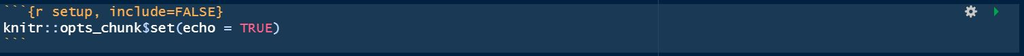

Options générales

Une option sympa aussi est celle qui permet de coloriser certains mots pour les faire ressortir. Pour cela il faut intégrer dans le **bloc setup** cette fonction :

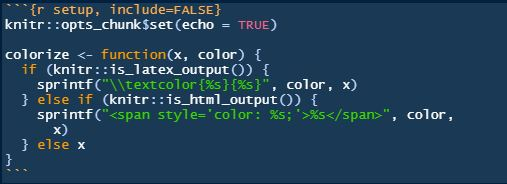

Fonction de colorisation des mots du document

# 5. Tableaux R

## 5.1. Tableaux croisés

Par défaut, les tableaux issus de la fonction `table` de R sont affichés comme ils apparaissent dans la console de R, en texte brut :

```r
tab <- table(abund_OTU_transvers_Cx$Sample, abund_OTU_transvers_Cx$Host)
tab
```

```
##
##       C. poicilipes C. tritaeniorhynchus
##   PD4             1                    0
##   PD5             1                    0
##   PF4             1                    0
##   PF5             1                    0
##   PK4             1                    0
##   PK5             1                    0
##   TD4             0                    1
##   TD5             0                    1
##   TF4             0                    1
##   TF5             0                    1
##   TK4             0                    1
##   TK5             0                    1
```

On peut améliorer leur présentation en utilisant la fonction `kable` de l’extension `knitr`. Celle-ci fournit un formatage adapté en fonction du format de sortie. On aura donc des tableaux *“propres”* que ce soit en HTML, PDF ou aux formats traitements de texte :

```r
library(knitr)
kable(tab)
```

|  | C. poicilipes | C. tritaeniorhynchus |
| --- | --- | --- |
| PD4 | 1 | 0 |
| PD5 | 1 | 0 |
| PF4 | 1 | 0 |
| PF5 | 1 | 0 |
| PK4 | 1 | 0 |
| PK5 | 1 | 0 |
| TD4 | 0 | 1 |
| TD5 | 0 | 1 |
| TF4 | 0 | 1 |
| TF5 | 0 | 1 |
| TK4 | 0 | 1 |
| TK5 | 0 | 1 |

De même, une autre manière d’améliorer la présentation des tableaux (ou dataframe) est l’utilisation de la fonction `datatable` du package `DT` (disponible sur github : détails [ici](https://rstudio.github.io/DT/)). Cette fonction possède beaucoup plus de fonctionnalité comme **l’édition du tableau** via la commande `editable = 'cell'`, la modification/personnalisation des noms de lignes ou colonnes `rownames = c() or colnames = c()` ou encore l’ajout d’un filtre aux colonnes `filter = 'top' or 'bottom'` :

```r
library(DT)
datatable(tab, editable = 'cell', filter = 'top')
```

|  | Var1 | Var2 | Freq |
| --- | --- | --- | --- |
| PD4 | PD4 | C. poicilipes | 1 |
| PD5 | PD5 | C. poicilipes | 1 |
| PF4 | PF4 | C. poicilipes | 1 |
| PF5 | PF5 | C. poicilipes | 1 |
| PK4 | PK4 | C. poicilipes | 1 |
| PK5 | PK5 | C. poicilipes | 1 |
| TD4 | TD4 | C. poicilipes | 0 |
| TD5 | TD5 | C. poicilipes | 0 |
| TF4 | TF4 | C. poicilipes | 0 |
| TF5 | TF5 | C. poicilipes | 0 |

[output cut: 14 more lines]

## 5.2. Tableaux de données

En ce qui concerne les tableaux de données (*tibble* ou *data frame*), l’affichage HTML par défaut se contente d’un affichage texte comme dans la console, très peu lisible dès que le tableau dépasse une certaine taille.

Une alternative est d’utiliser la fonction `paged_table`, qui affiche une représentation HTML paginée du tableau.

La ligne `df_print: paged` peut être ajoutée dans l’en tête en début de document pour signifier que tous les tableaux du document soient affichés automatiquement en format paginé.

# 6. Modèles de documents

## 6.1. Slides

Un usage intéressant est la création de diaporamas pour des présentations sous forme de *slides*. Le principe reste toujours le même : on mélange texte au format Markdown et code R, et R Markdown transforme le tout en présentations au format HTML ou PDF. En général les différents slides sont séparés au niveau de certains niveaux de titre.

Certains modèles de slides sont inclus avec *R Markdown*, notamment :

- **ioslides** et **Slidy** pour des présentations HTML
- **beamer** pour des présentations en PDF via LaTeX

[figure not shown]

Créer une présentation

## 6.2. Templates

Il existe différents *templates* permettant de changer le format et la présentation des documents générés. Une liste de ces formats et leur documentation associée est accessible depuis la page [formats](https://rmarkdown.rstudio.com/formats.html) de la documentation.

On notera notamment :

- le format **Distill**, adapté à des publications scientifiques ou techniques sur le Web
- le format **Tufte Handouts** qui permet de produire des documents PDF ou HTML dans un format proche de celui utilisé par Edward Tufte pour certaines de ses publications
- **rticles**, package qui propose des templates LaTeX pour plusieurs revues scientifiques

Enfin, l’extension `rmdformat` propose plusieurs modèles HTML adaptés notamment pour des documents longs (extension utilisée par exemple pour la création de ce document)

Là encore, la plupart du temps, ces modèles de documents proposent un template de départ lorsqu’on crée un nouveau document dans *RStudio* (**From Template**) :

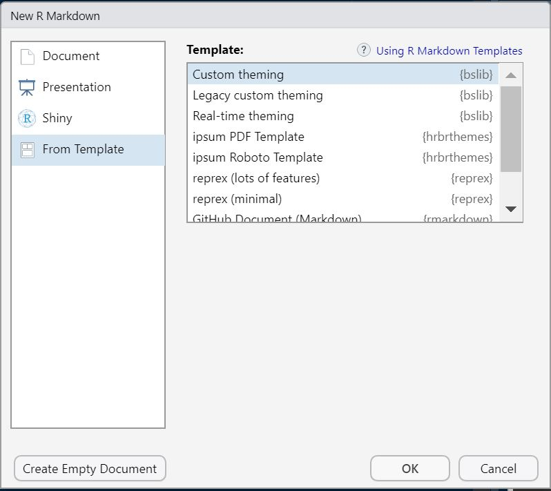

Créer un template

# 7. Ressources

Comme cité plusieurs fois dans le document, le [site officiel](https://rmarkdown.rstudio.com/formats.html) et le [guide de référence](https://www.rstudio.com/wp-content/uploads/2015/03/rmarkdown-reference.pdf) de l’extension Rmarkdown

La [page internet](https://juba.github.io/tidyverse/13-rmarkdown.html) que j’ai allègrement recopié en modifiant certaines petites choses

Et quelques autres pages internet intéressantes sur le sujet (*pour aller plus loin*) :

https://bookdown.org/yihui/rmarkdown/documents.html

https://stt4230.rbind.io/communication_resultats/redaction_r_markdown/#r-markdown

https://delladata.fr/guide-de-demarrage-en-r-markdown/